# Ford BeyWheels data findings

## by Grzegorz Lippe

## Investigation Overview

Lyft, formerly known as BayWheels shares its ride data on [lyft.com](https://www.lyft.com/bikes/bay-wheels/system-data).

## Dataset Overview

The data is provided in monthly sets and was combined to one 2019 data set. It provides information for Driver ID, Start Point, End Point, the start and end time, and therefor also the ride duration.

## Ride durations

- One interesting matter is the duration of rides.
- Do people use the service for shorter or longer trips?
- How many trips did they book?

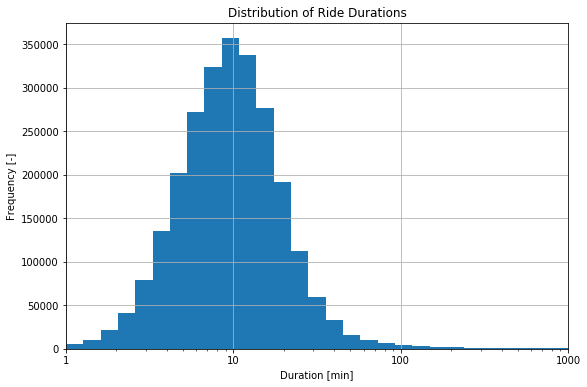

```python
bins = 10**np.linspace(0,3,30)
df.query("duration_min < 2000").plot(y='duration_min',
                                     kind='hist',
                                     bins=bins,
                                     figsize=(9,6),
                                     legend=False);
plt.xscale('log');
plt.xticks([1, 10, 100, 1000], ['1', '10', '100', '1000']);
plt.xlabel('Duration [min]');
plt.ylabel('Frequency [-]');
plt.title('Distribution of Ride Durations');
plt.xlim((1,1000))
plt.grid(True)
```

- People booket over 2.5 Million rides
- Most of the rides where shorter than 2 hours
- The ride distribution is log normal
- Half of the booked rides where shorter than 10 minutes

## How far did the different bikes go?

Investigateing the bikes ride durations, travelled distances and average speeds showed that most of the bikes travel only 200 km or 35 hours before they are replaced. But there is a significant difference beween "early" ID bikes and later versions.

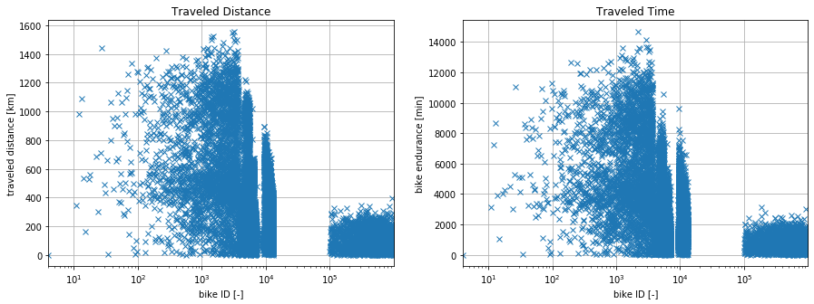

```python
_, ax = plt.subplots(1, 2, figsize=(15, 5))
df_grouped.plot(y='traveled_dist',
                linestyle='',
                marker='x',
                legend=False, ax=ax[0]);
ax[0].set_xscale('log')
ax[0].set_xlabel('bike ID [-]');
ax[0].set_ylabel('traveled distance [km]');
ax[0].set_title('Traveled Distance')
ax[0].grid(True)

df_grouped.plot(y='duration_min',
                linestyle='',
                marker='x',
                legend=False, ax=ax[1]);
ax[1].set_xscale('log')
ax[1].set_xlabel('bike ID [-]');
ax[1].set_ylabel('bike endurance [min]');
ax[1].set_title('Traveled Time')
ax[1].grid(True)
```

- There are two groups of bikes, bikes with an ID smaller than ~20'000 and higher than roundabout 95'000.
  - Bikes with IDs smaller than 20'000 travelled up to 1'600 kilometers and over 200 hours until decomissioning.
  - There are no bike IDs between 20k and 100k
  - Bikes with a higher ID (>90k) travel up to 400 kilometers and 40 hours until decomissioning.

## What are the profitable weekdays and seasons?

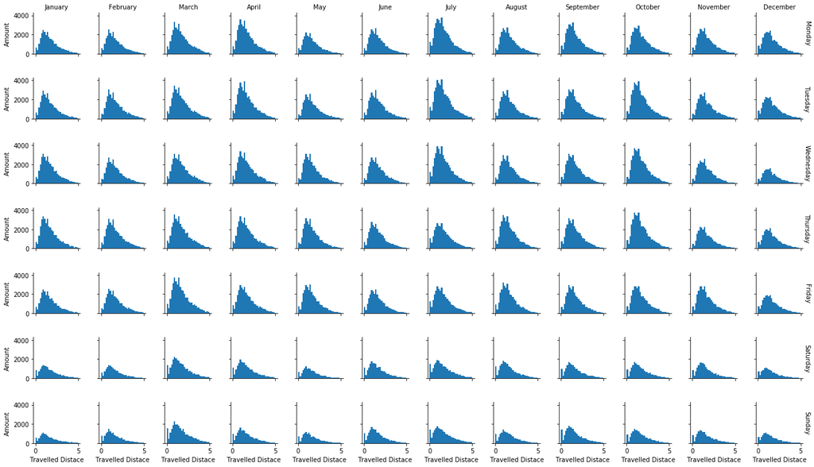

```python
# Initialize a grid of plots with an Axes for each walk
grid = sb.FacetGrid(df.query("start_station_longitude < -120 & traveled_dist < 5"),
                    col="month", row='weekday',
                    row_order=['Monday', 'Tuesday', 'Wednesday', 'Thursday', 'Friday', 'Saturday', 'Sunday'],
                    col_order=['January', 'February', 'March', 'April', 'May', 'June',
                               'July', 'August', 'September', 'October', 'November', 'December'],
                    margin_titles=True,
                    height=1.5);
grid.map(plt.hist, 'traveled_dist', bins=30);
grid.set_axis_labels("Travelled Distace", "Amount");
[plt.setp(ax.texts, text="") for ax in grid.axes.flat]
grid.set_titles(row_template = '{row_name}', col_template = '{col_name}');
```

- The amount of rides is quite stable over the year, with a slightly higher demand in July and April
- The weakest days are Saturdays and Sundays, so most of the people use the ride service to get to work, or back.